# TD1 - Correction

Outils de surveillance et analyses statistiques

INTECHMER - CT3 GEM

## Chargement des packages et des données

```r
library(tidyverse)
library(DT)
adult = read_csv("https://fxjollois.github.io/cours-2024-2025/intechmer-3a-add-tests/adult.csv")
```

## Tester les éléments suivants :

### Normalité de l’âge

L’échantillon est trop grand pour appliquer la fonction `shapiro.test()`, mais on peut analyser la distribution de la variable `age` graphiquement.

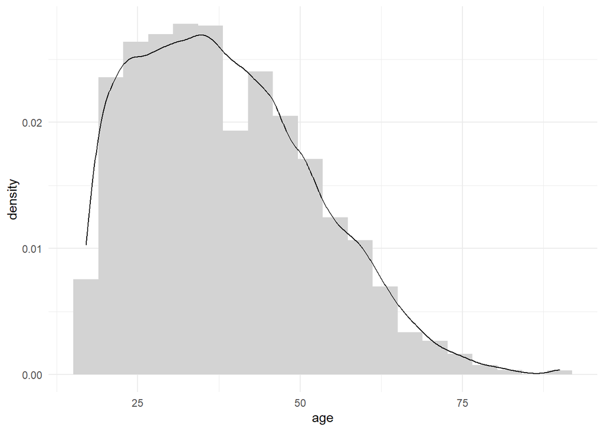

```r
ggplot(adult, aes(age)) +
  geom_histogram(aes(y = after_stat(density)),
                 fill = "lightgray", bins = 20) +
  geom_density() +
  theme_minimal()
```

### Normalité du nombre d’heures par semaine

Idem que pour `age`. Il faut noter qu’il y a un (très grand) pic à 40 heures.

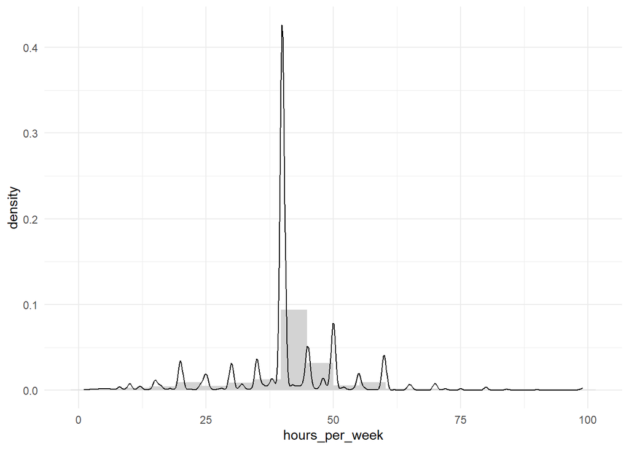

```r
ggplot(adult, aes(hours_per_week)) +
  geom_histogram(aes(y = after_stat(density)),
                 fill = "lightgray", bins = 20) +
  geom_density() +
  theme_minimal()
```

### Equi-répartition du sexe

On remarque qu’il y a bien plus d’hommes que de femmes.

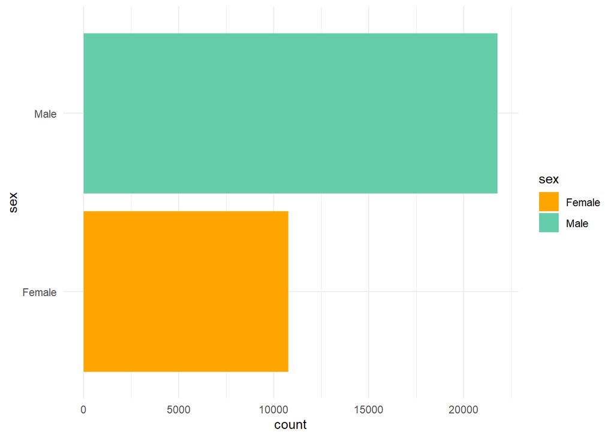

```r
ggplot(adult, aes(sex, fill = sex)) +
  geom_bar() +
  scale_fill_manual(values = c("orange", "mediumaquamarine")) +
  coord_flip() +
  theme_minimal()
```

La *p-value* est clairement inférieure à 5%.

```r
chisq.test(table(adult$sex))
```

```
##
##  Chi-squared test for given probabilities
##
## data:  table(adult$sex)
## X-squared = 3729, df = 1, p-value < 2.2e-16
```

### Equi-répartition du salaire (variable class)

On remarque qu’il y a bien plus de personnes gagnant moins de 50k$ que gagnant plus.

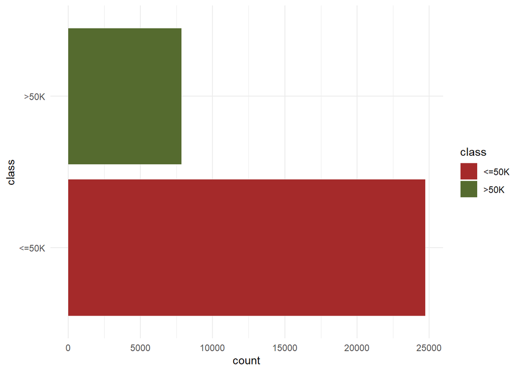

```r
ggplot(adult, aes(class, fill = class)) +
  geom_bar() +
  scale_fill_manual(values = c("brown", "darkolivegreen")) +
  coord_flip() +
  theme_minimal()
```

La *p-value* est ici aussi clairement inférieure à 5%.

```r
chisq.test(table(adult$class))
```

```
##
##  Chi-squared test for given probabilities
##
## data:  table(adult$class)
## X-squared = 8749.8, df = 1, p-value < 2.2e-16
```

## Identifier si les liens suivants sont réels :

### Âge et salaire

Les personnes gagnant plus de 50k$ sont globalement plus âgées que les autres.

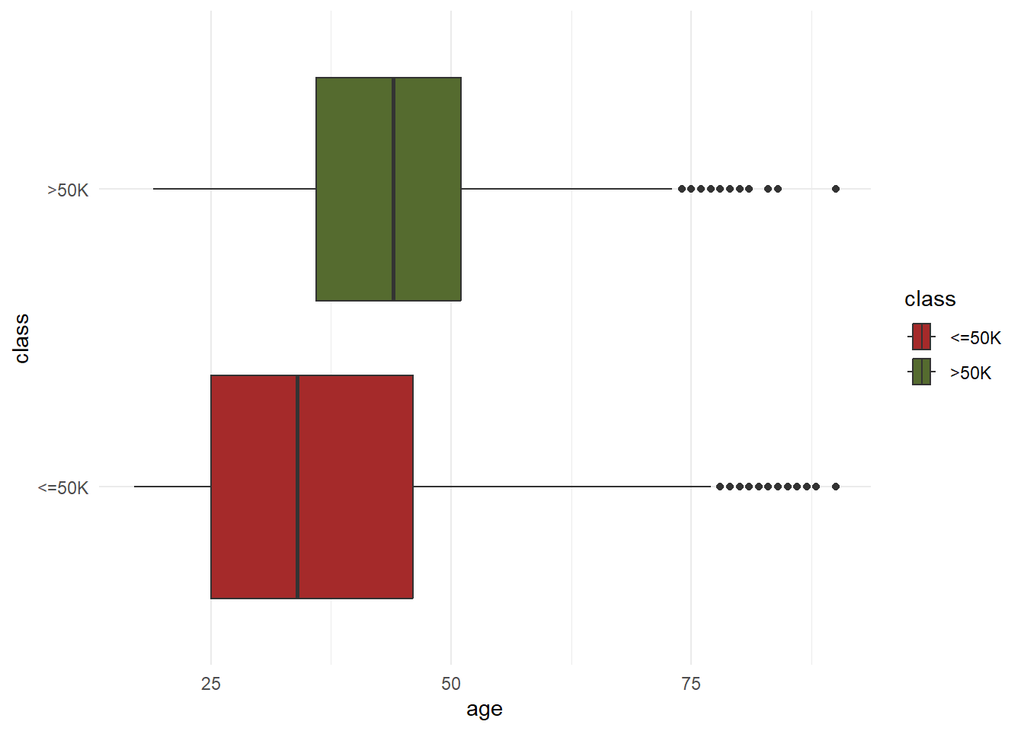

```r
ggplot(adult, aes(x = age, y = class, fill = class)) +
  geom_boxplot() +
  scale_fill_manual(values = c("brown", "darkolivegreen")) +
  theme_minimal()
```

On obtient une *p-value* largement inférieure à 5%, qui nous confirme notre observation.

```r
t.test(data = adult, age ~ class)
```

```
##
##  Welch Two Sample t-test
##
## data:  age by class
## t = -50.264, df = 17411, p-value < 2.2e-16
## alternative hypothesis: true difference in means between group <=50K and group >50K is not equal to 0
## 95 percent confidence interval:
##  -7.757250 -7.174955
## sample estimates:
## mean in group <=50K  mean in group >50K
##            36.78374            44.24984
```

### Nombre d’heures de travail par semaine et salaire

Les personnes gagnant plus de 50k$ travaillent plus longtemps que les autres.

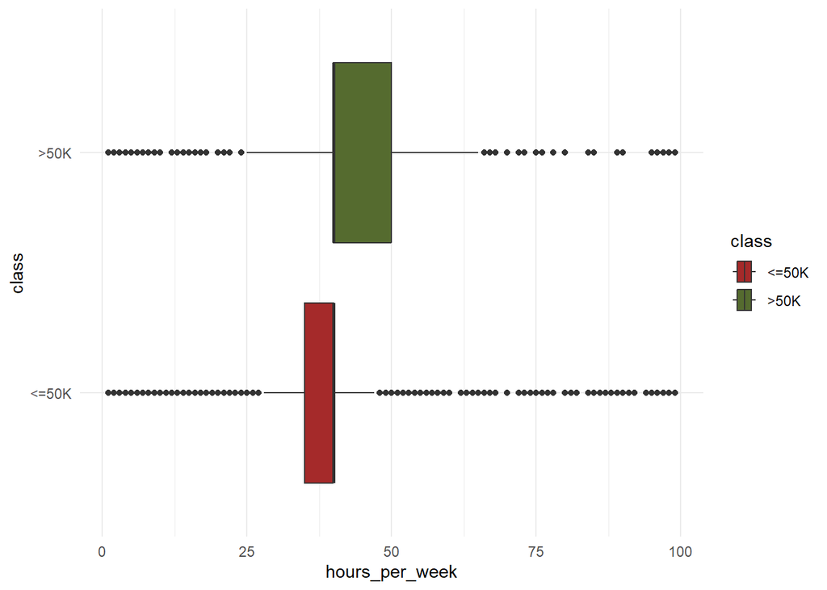

```r
ggplot(adult, aes(x = hours_per_week, y = class, fill = class)) +
  geom_boxplot() +
  scale_fill_manual(values = c("brown", "darkolivegreen")) +
  theme_minimal()
```

On obtient une *p-value* largement inférieure à 5%, qui nous confirme notre observation.

```r
t.test(data = adult, hours_per_week ~ class)
```

```
##
##  Welch Two Sample t-test
##
## data:  hours_per_week by class
## t = -45.123, df = 14570, p-value < 2.2e-16
## alternative hypothesis: true difference in means between group <=50K and group >50K is not equal to 0
## 95 percent confidence interval:
##  -6.920943 -6.344690
## sample estimates:
## mean in group <=50K  mean in group >50K
##            38.84021            45.47303
```

### Sexe et salaire

Il est clair que les hommes gagnent plus souvent plus de 50k$ que les femmes.

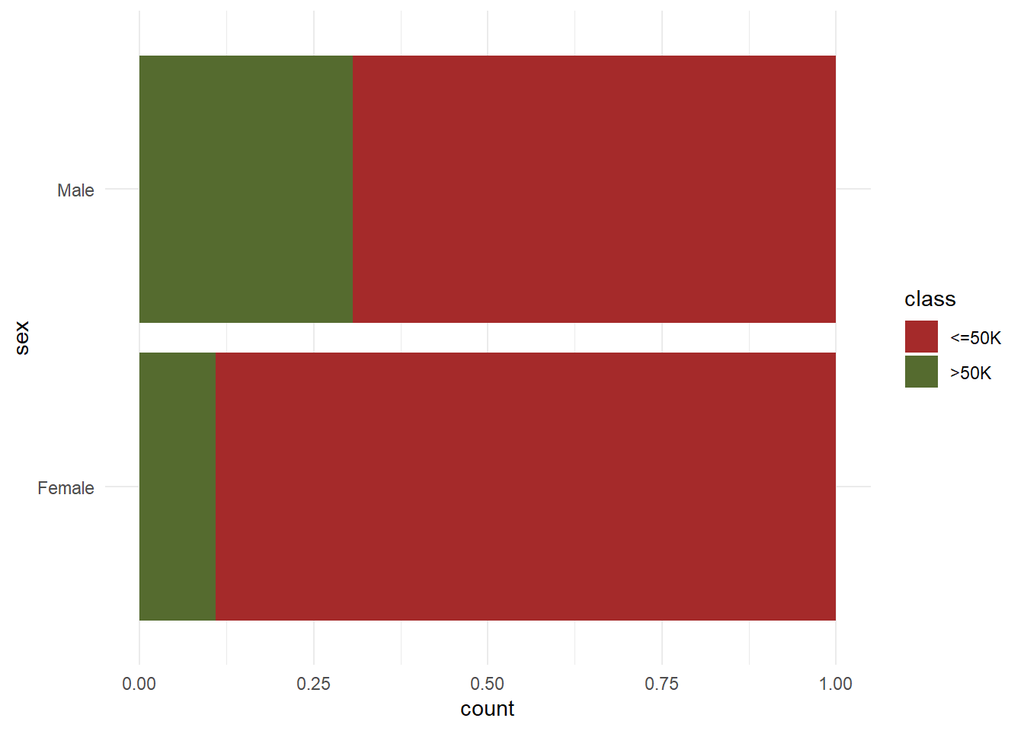

```r
ggplot(adult, aes(sex, fill = class)) +
  geom_bar(position = "fill") +
  coord_flip() +
  scale_fill_manual(values = c("brown", "darkolivegreen")) +
  theme_minimal()
```

Ce qui est confirmé par le test du $\chi^2$.

```r
chisq.test(table(adult$sex, adult$class))
```

```
##
##  Pearson's Chi-squared test with Yates' continuity correction
##
## data:  table(adult$sex, adult$class)
## X-squared = 1517.8, df = 1, p-value < 2.2e-16
```

### Catégorisation ethnique (variable race) et salaire

Les personnes *blanches* et d’origine *asiatiques* gagnent plus souvent plus de 50k$ que les autres origines.

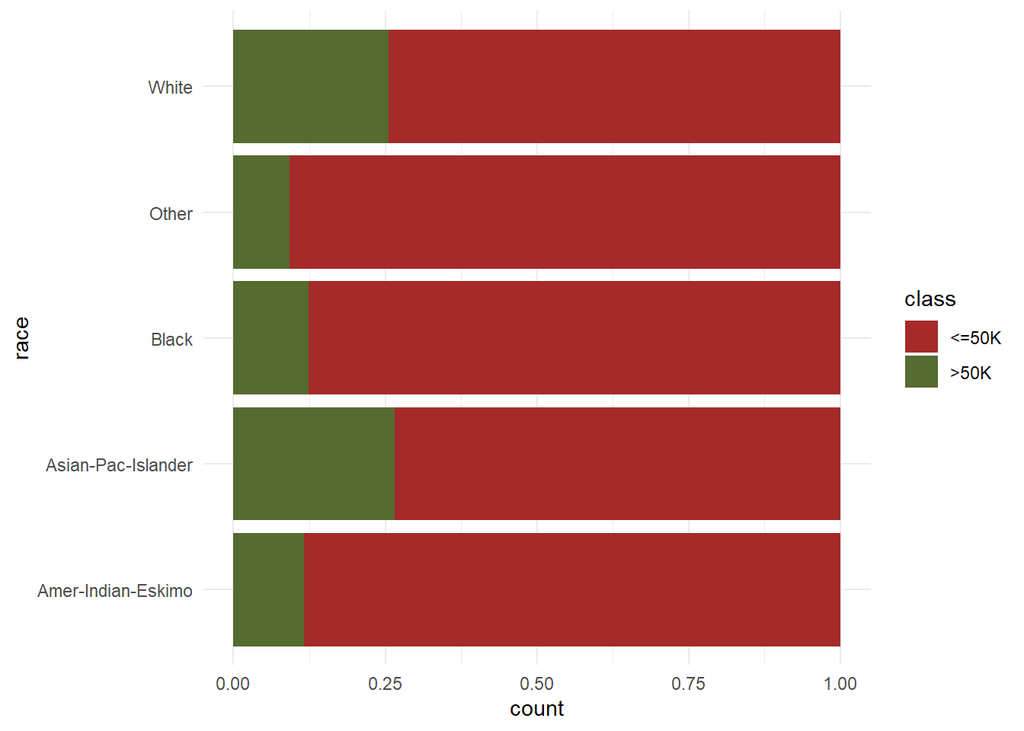

```r
ggplot(adult, aes(race, fill = class)) +
  geom_bar(position = "fill") +
  coord_flip() +
  scale_fill_manual(values = c("brown", "darkolivegreen")) +
  theme_minimal()
```

Idem, le test nous confirme la dépendance entre les deux variables.

```r
chisq.test(table(adult$race, adult$class))
```

```
##
##  Pearson's Chi-squared test
##
## data:  table(adult$race, adult$class)
## X-squared = 330.92, df = 4, p-value < 2.2e-16
```

### Âge et nombre d’heures de travail par semaine

Il ne semble pas très clair qu’il y ait un lien entre les deux variables

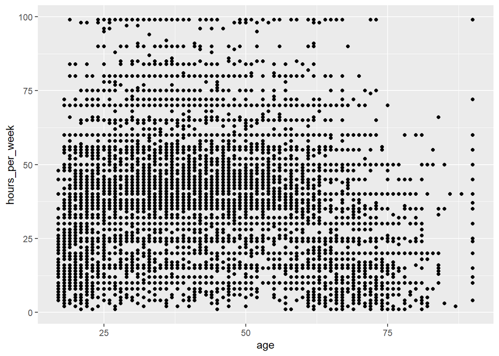

```r
ggplot(adult, aes(age, hours_per_week)) +
  geom_point()
```

Le coefficient de corrélation est très faible (0.069) mais le test nous indique qu’il est différent de 0. Toutefois, le lien est très très faible.

```r
cor.test(adult$age, adult$hours_per_week)
```

```
##
##  Pearson's product-moment correlation
##
## data:  adult$age and adult$hours_per_week
## t = 12.436, df = 32559, p-value < 2.2e-16
## alternative hypothesis: true correlation is not equal to 0
## 95 percent confidence interval:
##  0.05793717 0.07955810
## sample estimates:
##        cor
## 0.06875571
```